# 20192_M2.955_PEC4-Solucion

[figure not shown]

M2.855 · Modelos avanzados de minería de datos · PEC4

2019-2 · Máster universitario en Ciencia de datos (Data science)

Estudios de Informática, Multimedia y Telecomunicación

# PEC 4: Series temporales y Combinación de clasificadores

Está práctica está dividida en dos partes:

- En el primer ejercicio veremos como descomponer y componer series temporales para realizar predicciones a futuro.
- En el segundi ejercicio estudiaremos diferentes métodos de combinación de clasificadores.

Para esta PEC se deben usar **únicamente las librerías que se importan a continuación**. Si se desea usar otra librería hay que consultarlo con el tutor/tutora del aula.

**Importante: Cada uno de los ejercicios puede suponer varios minutos de ejecución, por lo que la entrega debe hacerse en formato notebook y en formato html donde se vea el código y los resultados y comentarios de cada ejercicio. Para exportar el notebook a html puede hacerse desde el menú File $\to$ Download as $\to$ HTML.**

```python
import pickle

import scipy.stats
import numpy as np
import pandas as pd
import matplotlib as mpl
from sklearn import svm
from sklearn import ensemble
from matplotlib import pyplot as plt
from sklearn.decomposition import PCA
from sklearn.metrics import accuracy_score
from sklearn.preprocessing import OneHotEncoder
from sklearn.tree import DecisionTreeClassifier
from sklearn.linear_model import LinearRegression
from sklearn.neighbors import KNeighborsClassifier
from sklearn.model_selection import cross_val_score
from sklearn.model_selection import train_test_split
from statsmodels.tsa.statespace.sarimax import SARIMAX
from statsmodels.graphics.tsaplots import plot_pacf, plot_acf

%matplotlib inline
```

# 1. Series temporales (5 puntos)

En este primer ejercicio trabajaremos las series temporales. Para ello usaremos el dataset *AirPassangers* que contiene información del número de vuelos que se realizaron a lo largo de muchos años.

Empezaremos leyendo los datos y observando gráficamente su distribución. Como se puede apreciar es un claro caso de serie temporal, con heterocedasticidad, tendencia, periodo y ruido. A lo largo de este ejercicio trataremos cada uno de estos puntos.

```python
data = pd.read_csv('AirPassengers.csv', parse_dates=['Month'], index_col='Month', header=0)
data.head()
```

| Month | Passengers |
| --- | --- |
| 1949-01-01 | 112 |
| 1949-02-01 | 118 |
| 1949-03-01 | 132 |
| 1949-04-01 | 129 |
| 1949-05-01 | 121 |

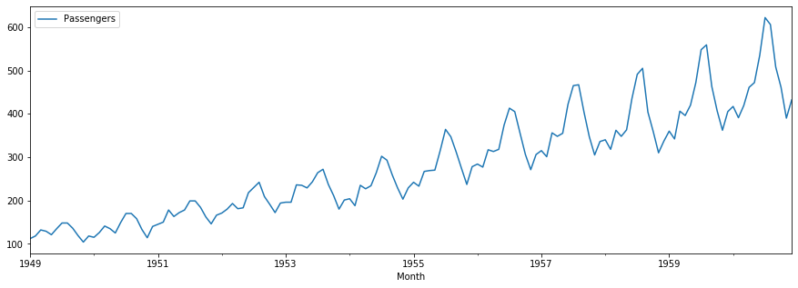

```python
data.plot(figsize=(15, 5))
```

Antes de empezar a tratar las diferentes componenetes de una serie temporal, eliminaremos del dataset original un par de años de datos. Así cuando hagamos una predicción a futuro podremos comprobar si se ajusta a los datos reales.

```python
TEST_SIZE = 24
train, test = data.iloc[:-TEST_SIZE], data.iloc[-TEST_SIZE:]
x_train, x_test = np.array(range(train.shape[0])), np.array(range(train.shape[0], data.shape[0]))
train.shape, x_train.shape, test.shape, x_test.shape
```

```
((120, 1), (120,), (24, 1), (24,))
```

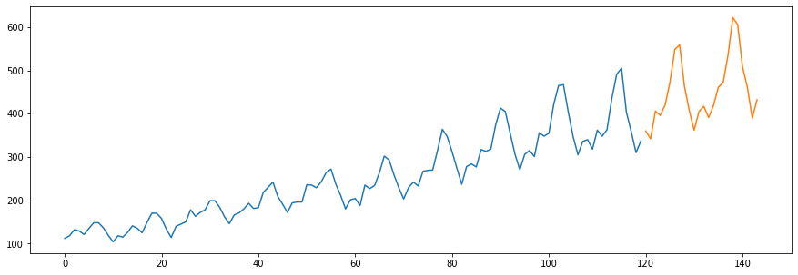

```python
fig, ax = plt.subplots(1, 1, figsize=(15, 5))
ax.plot(x_train, train)
ax.plot(x_test, test)
```

## 1.1 Componentes de la serie temporal

### 1.1.a. Heterocedasticidad

Se dice que una serie temporal tiene heterocedasticidad cuando la variancia varía con el tiempo (https://es.wikipedia.org/wiki/Heterocedasticidad). En nuestro caso, observamos que tenemos heterocedasticidad, ya que la amplitud de onda varía con el tiempo. En este primer apartado debéis eliminar la heterocedasticidad de la serie temporal. Es decir, que la diferencia entre el mínimo y el máximo de la estacionalidad (anual) sea más o menos la misma a lo largo del tiempo.

**Implementación:** Transformación de los datos para eliminar la heterocedasticidad. Para hacerlo debéis transformar los datos aplicando la función que consideréis que elimina mejor la heterocedasticidad en el dataset, provad con las tres funciones siguientes: - exponencial - logarítmica - raiz cuadrada y decidid cual de las tres funciona mejor para eliminar la heterocedasticidad. Estas funciones ya están implementadas en numpy. Mostrad gráficamente el dataset transformado.

**Solución:**

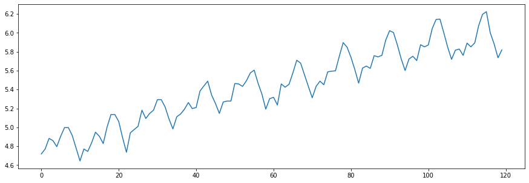

```python
#############################################
# SOLUCION                                  #
#############################################

train_log = np.log(train)

fig, ax = plt.subplots(1, 1, figsize=(15, 5))
ax.plot(x_train, train_log)
```

### 1.1.b. Tendencia

La tendencia es el comportamento que tiene los datos a largo plazo (https://miro.medium.com/max/1872/1*rDQL2fAp_X_dgAHNZuwRfw.png). En nuestra serie temporal tenemos una tendencia lineal creciente. En este apartado debéis eliminar la tendencia, quedando una serie temporal con tendencia constante.

**Implementación:** Eliminar la tendencia de los datos. Como observando la serie podemos apreciar que tenemos una tendencia lineal, podemos ajustar una regresión lineal (usando scikit-learn) y sustraerla a los datos originales (sin heterocedasticidad). Graficar los datos sin tendencia.

**Solución:**

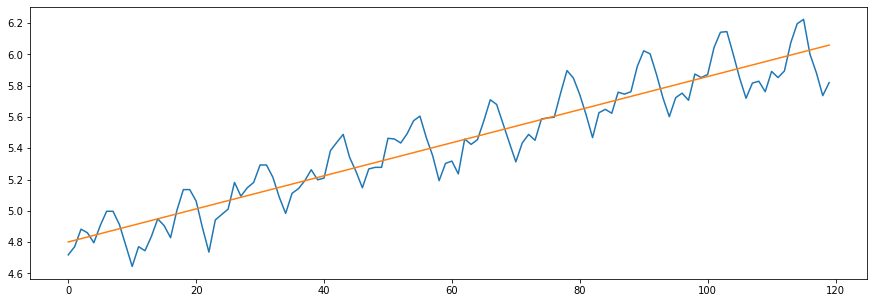

```python
#############################################
# SOLUCION                                  #
#############################################

model = LinearRegression()
model.fit(x_train.reshape(-1, 1), train_log.values)
train_log_trend = model.predict(x_train.reshape(-1, 1))

fig, ax = plt.subplots(1, 1, figsize=(15, 5))
ax.plot(x_train, train_log)
ax.plot(x_train, train_log_trend)
```

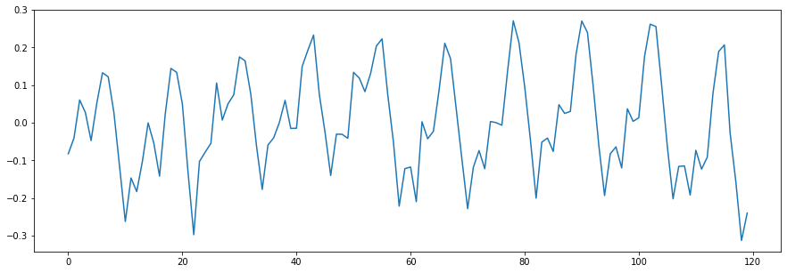

```python
#############################################
# SOLUCION                                  #
#############################################

train_log_trend = (train_log - model.predict(x_train.reshape(-1, 1))).values.squeeze()

fig, ax = plt.subplots(1, 1, figsize=(15, 5))
ax.plot(x_train, train_log_trend)
```

### 1.1.c. Estacionalidad

Definimos estacionalidad como la variación cíclica que se produce en los datos (https://es.wikipedia.org/wiki/Estacionalidad). En este apartado se debe encontrar y eliminar la estacionalidad.

#### 1.1.c.a. Encontrar el periodo de la estacionalidad

**Implementación:** En primer lugar tenéis que encontrar el ciclo, es decir, cada cuando se repiten los datos. Para encontrarlo podéis usar l'autocorrelación (*numpy* te permite obtener los coeficientes de correlación). La idea es que se tiene que comparar: - La serie original con la serie empezando en el segundo punto (es decir, serie[1:]) - La serie original con la serie empezando en el tercer punto (es decir, serie[2:]) - ... En el momento en que vuelva a empezar el ciclo, la serie será muy parecida a la serie original, y, por lo tanto, la correlación será muy elevada. El punto donde la correlación sea máxima, será el ciclo de la serie. Mostrar gráficamente los coeficientes de los 22 primeros valores de autocorrelación y determinar su valor máximo, este será nuestra estacionalidad. NOTA: Si usais *numpy* para encontrar los coeficientes de correlación, las dos series que comparéis deben de tener la misma longitud. Para representar la serie original podéis eliminar los valores del final para que tenga la misma longitud que la serie "movida". Por ejemplo, en el primer caso podéis comparar serie[1:] con serie[:-1].

**Solución:**

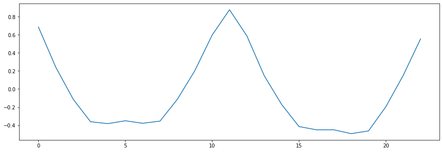

```python
#############################################
# SOLUCION                                  #
#############################################

corr_coefficients = []

for i in range(1, 24):
    corr_coefficients.append(np.corrcoef(train_log_trend[i:], train_log_trend[:-i])[0,1])

fig, ax = plt.subplots(1, 1, figsize=(15, 5))
ax.plot(range(len(corr_coefficients)), corr_coefficients)
```

#### 1.1.c.b. Aplicar un modelo SARIMA

Para tratar la estacionalidad aplicaremos un modelo SARIMA. Las siglas corresponden a "stationality ARIMA", es decir, un modelo ARIMA con estacionalidad (la que acabamos de encontrar).

El modelo ARIMA nos va a permitir tratar el ruido que queda al eliminar la heterocedasticidad, tendencia y estacionalidad. Para hacerlo tiene en cuenta las siguientes componentes:

- AR: auto-regressive, se denomina *p*. Tiene en cuenta la correlación con sus lags, es decir, mira si las observaciones pasadas afectan para calcular el siguiente punto.
- I: integrated, se denomina *d*. Es el orden de diferenciación, en nuestro caso no es necesario, puesto que la serie ya no tiene heterocedasticidad ni tendencia.
- MA: moving-average, se denomina *q*. Tiene en cuenta la correlación con los lags de los errores, es decir, una vez se ha aplicado el modelo, mira los errores del modelo versus los datos reales.

Para más información sobre los ARIMA podéis consultar este link: https://otexts.com/fpp2/arima.html

Los modelos SARIMA dependen de varios parámetros (p,d,q)(P,D,Q)s, donde los primeros (minúsculas) corresponden a AR, I, MA de la serie normal, u los segundos (mayúsculas) a AR, I, MA con estacionalidad.

Para encontrar estos parámetros tenemos que mirar los gráficos PACF (*partial autocorrelation function*) y ACF (*autocorrelation function*).

El gráfico PACF nos determina el parámetro *p*, es decir, la AR.

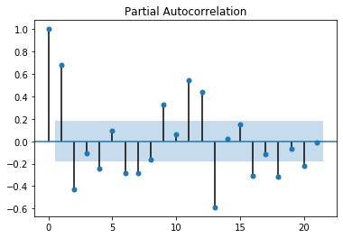

```python
# Supongamos que los datos sin heterocedasticidad ni tendencia se llaman train_log_trend
plot_pacf(train_log_trend)
plt.show()
```

Para leer este gráfico, simplemente nos tenemos que fijar en los valores que salen fuera del intervalo de confianza (zona azul).

Veamos ahora el gráfico ACF, este determinará el valor de *q*.

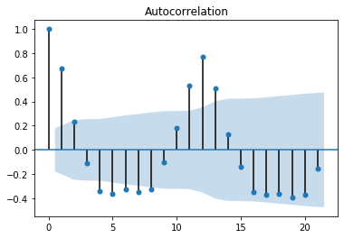

```python
# Supongamos que los datos sin heterocedasticidad ni tendencia se llaman train_log_trend
plot_acf(train_log_trend)
plt.show()
```

Este gráfico se lee igual que el anterior. Nada más empezar hay un valor fuera del intervalo, con lo cual **q = 1**. Cuando se repite el ciclo, es decir, a partir del valor 11, hay tres valores fuera del intervalo, con lo cual **Q = 3**.

Como los datos no tienen ni tendencia ni heterocedasticidad, **d = D = 0**.

Como hemos visto en el apartado anterior, el ciclo es 12, con lo cual **s = 12**.

**Implementación:** Aplica un modelo SARIMA a los datos sin heterocedasticidad ni tendencia. Puedes usar SARIMAX (de *statsmodels.tsa.statespace.sarimax*) con los parámetros que acabamos de ver. Mostrar gráficamente el resultado del modelo junto con la serie original para comparar si se ajusta bien.

**Solución:**

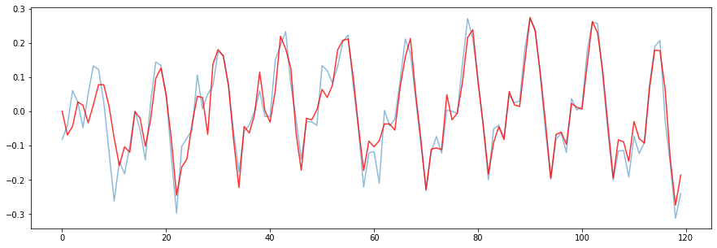

```python
model_sarima = SARIMAX(train_log_trend, order=(1, 0, 1), seasonal_order=(2, 0, 3, 12))
results = model_sarima.fit()

ax, fig = plt.subplots(figsize=(15,5))
plt.plot(train_log_trend, alpha=0.5)
plt.plot(results.fittedvalues, color='red', alpha=0.8)
```

## 1.2. Predicción

Vamos a predecir los dos proximos años y comparar la predicción con los datos reales. Seguiremos los siguientes pasos:

- Generar la predicción con el SARIMA
- Añadir tendencia
- Añadir heterocedasticidad

### 1.2.a. Preddicción SARIMA

Utilizaremos el modelo SARIMA que hemos fitado antes para predecir los dos próximos años.

**Implementación:** Genera dos años de datos mediante el modelo SARIMA fitado en el apartado anterior. Grafica toda la serie (sin heterocedasticidad ni tendencia), diferenciando con colores diferentes la serie real de los dos años de predicción.

**Solución:**

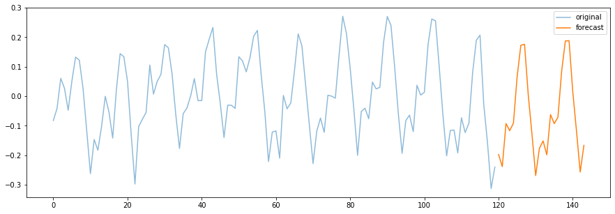

```python
#############################################
# SOLUCION                                  #
#############################################

pred = results.forecast(TEST_SIZE)

ax, fig = plt.subplots(figsize=(15,5))
plt.plot(train_log_trend, alpha=0.5, label='original')
plt.plot(range(120, 120 + TEST_SIZE), pred, label='forecast')
plt.legend()
```

### 1.2.b. Tendencia

Anteriormente hemos visto que los datos de la serie temporal tienen una tendencia lineal y la hemos calculado mediante una regresión lineal. Vamos a añadir esta tendencia a nuestra predicción.

**Implementación:** Añadir a la serie anterior, la tendencia encontrada en el apartado 1.1.b. Mostrar gráficamente toda la serie (sin heterocedasticitat), diferenciando con colores diferentes la serie real de los dos años de predicción.

**Solución:**

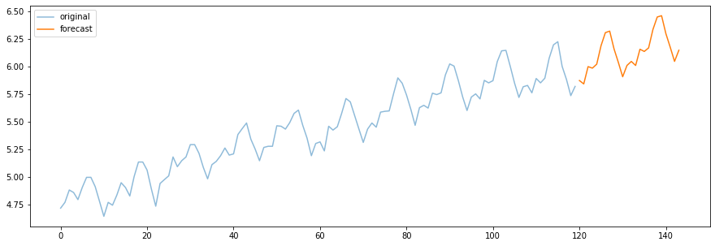

```python
#############################################
# SOLUCION                                  #
#############################################

pred_trend = pred + model.predict(x_test.reshape(-1, 1)).squeeze()

fig, ax = plt.subplots(1, 1, figsize=(15, 5))
plt.plot(range(120), train_log, alpha=0.5, label='original')
plt.plot(range(120, 120 + TEST_SIZE), pred_trend, label='forecast')
plt.legend()
```

### 1.2.c. Heterocedasticidad

En el primer apartado de esta práctica hemos visto que la serie temporal tiene heterocedasticidad y la hemos eliminado transformando los datos. En este apartado haremos la transfromación inversa para añadir heterocedasticidad a nuestra predicción.

**Implementació:** Añadir a la serie anterior, la heterocedasticidad aplicando la función inversa a la encontrada en el apartado 1.1.a. Mostrar gráficamente toda la serie, diferenciando con colores diferentes la serie real de los dos años de predicción.

**Solución:**

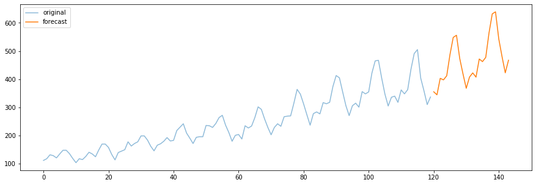

```python
#############################################
# SOLUCION                                  #
#############################################

final_pred = np.exp(pred_trend)

fig, ax = plt.subplots(1, 1, figsize=(15, 5))
plt.plot(range(120), train, alpha=0.5, label='original')
plt.plot(range(120, 120 + TEST_SIZE), final_pred, label='forecast')
plt.legend()
```

**Implementación:** Añade al gráfico anterior la serie real para los dos años de predicción.

**Solución:**

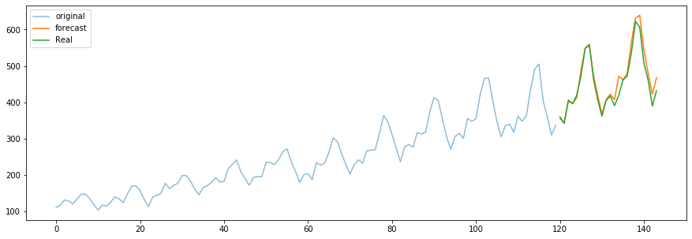

```python
#############################################
# SOLUCION                                  #
#############################################

fig, ax = plt.subplots(1, 1, figsize=(15, 5))
plt.plot(range(120), train, alpha=0.5, label='original')
plt.plot(range(120, 120 + TEST_SIZE), final_pred, label='forecast')
ax.plot(x_test, test, label='Real')
plt.legend()
```

## 2. Combinación de clasificadores (5 puntos)

Para este ejercicio usaremos el dataset *cars.csv*. Este dataset contiene datos sobre pruebas hechas en un modelo de coche, en concreto se estudia si el coche derrapará o no en una curva en función de la velocidad que lleva. El dataset contiene las siguientes columnas:

- speed: velocidad que lleva el coche
- angle: ángulo de la curva
- succeed: 1 si el coche coge la curva sin problemas, 0 si el coche derrapa

A la primera parte de este ejercicio veremos la combinación de clasificadores en paralelo mediante las tecnicas de *Bagging* y *Boosting*.

La segunda parte pretende mejorar los resultados aplicando tecnicas de combinación secuencial de clasificadores: *Stacking* y *Cascading*.

Para empezar, vamos a visualizar el dataset.

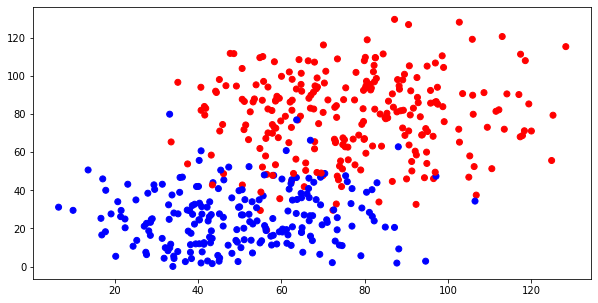

```python
cars = pd.read_csv('cars.csv')

fig, ax = plt.subplots(1, 1, figsize=(10, 5))
plt.scatter(cars['speed'], cars['angle'], c = cars['succeed'], cmap = 'bwr')
```

Para poder probar varios modelos, primero vamos a dividir el dataset entre train y test.

Para que todos obtengáis los mismos resultados y poder comentar dudas por el foro, fijaremos la seed para obtener los mismos datasets de train y test.

Como en este ejercicio trataremos *stacking* y *cascading*, y ambos se aplican sobre el conjunto de test, haremos un *split* del 50% para tener un poco más de base al aplicar estas dos técnicas.

```python
X = cars.drop(columns = 'succeed')
y = cars['succeed']

X_train, X_test, y_train, y_test = train_test_split(X, y, test_size = 0.5, random_state = 34)
```

Para visualizar gráficamente como funcionan los diferentes modelos, dibujaremos las fronteras de decisión. Lo que nos interesa es ver la forma que tienen (si es cuadriculada, suave, ...), y si hay zonas de indecisión (areas blancas). La idea es entender por que el moldelo que aplicamos tiene estas características.

Para dibujar las fronteras de decisión podéis usar la siguiente función.

```python
# Fem la meshgrid amb els valors màxim i mínim de 'x' i 'y'.
x_min, x_max = X['speed'].min()-0.1, X['speed'].max()+0.1
y_min, y_max = X['angle'].min()-0.1, X['angle'].max()+0.1

def plot_decision_boundaries(x, y, labels, model,
                             x_min=x_min,
                             x_max=x_max,
                             y_min=y_min,
                             y_max=y_max,
                             grid_step=1):

    xx, yy = np.meshgrid(np.arange(x_min, x_max, grid_step),
                         np.arange(y_min, y_max, grid_step))

    # Predim el classifier amb els valors de la meshgrid.
    Z = model.predict_proba(np.c_[xx.ravel(), yy.ravel()])[:,1]

    # Fem reshape per tenir el format correcte.
    Z = Z.reshape(xx.shape)

    # Seleccionem una paleta de color.
    arr = plt.cm.coolwarm(np.arange(plt.cm.coolwarm.N))
    arr_hsv = mpl.colors.rgb_to_hsv(arr[:,0:3])
    arr_hsv[:,2] = arr_hsv[:,2] * 1.5
    arr_hsv[:,1] = arr_hsv[:,1] * .5
    arr_hsv = np.clip(arr_hsv, 0, 1)
    arr[:,0:3] = mpl.colors.hsv_to_rgb(arr_hsv)
    my_cmap = mpl.colors.ListedColormap(arr)

    # Fem el gràfic de les fronteres de decisió.
    fig, ax = plt.subplots(figsize=(7,7))
    plt.pcolormesh(xx, yy, Z, cmap=my_cmap)

    # Afegim els punts.
    ax.scatter(x, y, c=labels, cmap='coolwarm')
    ax.set_xlim(xx.min(), xx.max())
    ax.set_ylim(yy.min(), yy.max())
    ax.grid(False)
```

## 2.1. Combinació paral·lela de classificadors

### 2.1.1. Arbre de decisió

Per poder comparar l'augment de *performance* obtingut a mida que anem aplicant tècniques noves, utilitzarem com a *baseline* un simple arbre de decisió.

**Implementación:** Entrena un árbol de decisión sobre el conjunto de datos de train con profundidad máxima de 3 niveles (aplicaremos la misma restricción en las siguientes secciones). A continuación evalua sobre test y calcula su precisión aplicando validación cruzada con 5 conjuntos. Finalmente, dibuja la frontera de decisión. Sugerencia: usar el módulo *cross_val_score* de *sklearn*. Para aprender más sobre *cross validation* y sobre como usar estos módulos, os recomendamos los siguientes enlaces: - http://scikit-learn.org/stable/modules/cross_validation.html - http://scikit-learn.org/stable/modules/generated/sklearn.model_selection.cross_val_score.html

**Solución:**

```python
#############################################
# SOLUCION                                  #
#############################################

clf = DecisionTreeClassifier(max_depth=3)

cvscores = cross_val_score(clf, X_train, y_train, cv=5)
print("Precisió mitjana obtinguda amb CV: {:.2f} +/- {:.2f} %".format(np.mean(cvscores)*100, np.std(cvscores)*100))
```

```
Precisió mitjana obtinguda amb CV: 91.34 +/- 1.38 %
```

```python
clf.fit(X_train, y_train)
y_pred_tree = clf.predict(X_test)
accuracy_score(y_pred_tree, y_test)
```

```
0.9181034482758621
```

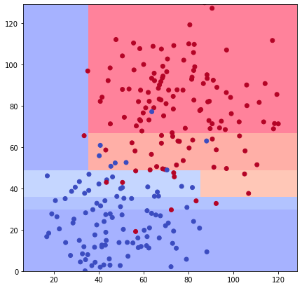

```python
plot_decision_boundaries(X_test['speed'], X_test['angle'], y_test, clf)
```

**Análisis:** Analizad los resultados obtenidos y, en especial, la frontera de decisión.

### 2.1.2.a. *Bagging*

La idea básica del bagging es utilizar el conjunto de entrenamiento original para generar centenares o miles de conjuntos similares usando muestreo con reemplazo. En este concepto está basado el algoritmo Random Forest, la combinación de varios árboles de decisión, cada uno entrenado con una realización diferente de los datos. La decisión final del clasificador combinado (la Random Forest) se toma por mayoría, dando el mismo peso a todas las decisiones parciales tomadas por los clasificadores base (los árboles).

**Implementación:** Entrena un *random forest* sobre el conjunto de datos de train con **20 árboles** de decisión y **profundidad máxima de 3** niveles. A continuación evalua sobre test y calcula su precisión aplicando validación cruzada con 5 conjuntos. Finalmente, dibuja la frontera de decisión. Sugerencia: usar el módulo *RandomForestClassifier* de *sklearn*. Per apender a usar este módulo os recomendamos el siguiente enlace: - http://scikit-learn.org/stable/modules/generated/sklearn.ensemble.RandomForestClassifier.html

**Solución:**

```python
#############################################
# SOLUCION                                  #
#############################################

clf = ensemble.RandomForestClassifier(n_estimators=20, max_depth=3)

cvscores = cross_val_score(clf, X_train, y_train, cv=5)
print("Precisió mitjana obtinguda amb CV: {:.2f} +/- {:.2f} %".format(np.mean(cvscores)*100, np.std(cvscores)*100))
```

```
Precisió mitjana obtinguda amb CV: 92.63 +/- 2.24 %
```

```python
clf.fit(X_train, y_train)
y_pred_random_forest = clf.predict(X_test)
accuracy_score(y_pred_random_forest, y_test)
```

```
0.9137931034482759
```

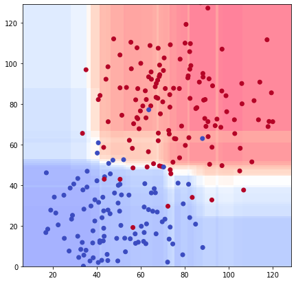

```python
plot_decision_boundaries(X_test['speed'], X_test['angle'], y_test, clf)
```

**Análisis:** Analizad los resultados obtenidos y, en especial, la frontera de decisión.

**Solución:** Obtenemos una buena precisión en test, un poco por debajo de la de train . También notamos una mejora respecto a un simple árbol de decisión. (Esto puede variar dependiendo de los datasets de train y test). La frontera de decisión no es nada fluida, esto es porque cada corte representa una división del árbol. De hecho, al haver fijado max_depth = 3, podemos ver claramente los tres cortes. En este caso si que hay zona de incertidumbre, esto es debido a que cada punto se ha generado mediante la probabilidad de 20 árboles. Si hay puntos que la mitad de los árboles han estimado que son de una clase, mientras que la otra mitad han estimado lo contrario, esta zona queda pintada de blanco, ya que el random forest no es capaz de tomar una decisión.

### 2.1.3. *Boosting*

En el sistema de Boosting se combinan varios clasificadores débiles sequencialmente, y en cada uno de ellos se da más peso a los datos que han sido erróneamente clasificados en las combinaciones anteriores, para que se concentre así en los casos más difíciles de resolver.

**Implementación:** Entrena un *gradient boosting* sobre el conjunto de datos de train con **20 árboles** de decisión y **profundidad máxima de 3** niveles. A continuación evalua sobre test y calcula su precisión aplicando validación cruzada con 5 conjuntos. Finalmente, dibuja la frontera de decisión. Sugerencia: usar el módulo *GradientBoostingClassifier* de sklearn. Per apender a usar este módulo os recomendamos el siguiente enlace: - http://scikit-learn.org/stable/modules/generated/sklearn.ensemble.GradientBoostingClassifier.html

**Solución:**

```python
#############################################
# SOLUCION                                  #
#############################################

clf = ensemble.GradientBoostingClassifier(n_estimators=20, max_depth=3)

cvscores = cross_val_score(clf, X_train, y_train, cv=5)
print("Precisió mitjana obtinguda amb CV: {:.2f} +/- {:.2f} %".format(np.mean(cvscores)*100, np.std(cvscores)*100))
```

```
Precisió mitjana obtinguda amb CV: 92.21 +/- 2.20 %
```

```python
clf.fit(X_train, y_train)
y_pred_gradient_boosting = clf.predict(X_test)
accuracy_score(y_pred_gradient_boosting, y_test)
```

```
0.9094827586206896
```

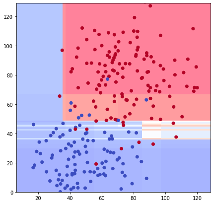

```python
plot_decision_boundaries(X_test['speed'], X_test['angle'], y_test, clf)
```

**Análisis:** Analizad los resultados obtenidos y, en especial, la frontera de decisión.

**Solución:** Obtenemos una buena precisión en test, un poco por debajo de la de train . También notamos una mejora respecto a un simple árbol de decisión. Mejora prácticamente inexistente respecto al random forest. (Esto puede variar dependiendo de los datasets de train y test). La frontera de decisión no es nada fluida, esto es porque cada corte representa una división del árbol. De hecho, al haver fijado max_depth = 3, podemos ver claramente los tres cortes. En este caso, por el mismo motivo que en el random forest, si que hay zona de incertidumbre.

## 2.2. Combinación secuencial de clasificadores base diferentes

Para poder hacer combinación secuencial de modelos, necessitamos tener varios modelos diferentes entrenados.

En nuestro caso, ya tenemos un árbol de decisión. Vamos a entrenar un par de modelos más.

### 2.2.1 KNN (k vecinos más próximos)

**Implementación:** Entrena un *k-neighbors* con 2 vecinos sobre el conjunto de datos de train. A continuación evalua sobre test y calcula su precisión aplicando validación cruzada con 5 conjuntos. Finalmente, dibuja la frontera de decisión.

**Solución:**

```python
#############################################
# SOLUCION                                  #
#############################################

clf = KNeighborsClassifier(n_neighbors=2)

cvscores = cross_val_score(clf, X_train, y_train, cv=5)
print("Precisió mitjana obtinguda amb CV: {:.2f} +/- {:.2f} %".format(np.mean(cvscores)*100, np.std(cvscores)*100))
```

```
Precisió mitjana obtinguda amb CV: 89.18 +/- 4.13 %
```

```python
clf.fit(X_train, y_train)
y_pred_knn = clf.predict(X_test)
accuracy_score(y_pred_knn, y_test)
```

```
0.8706896551724138
```

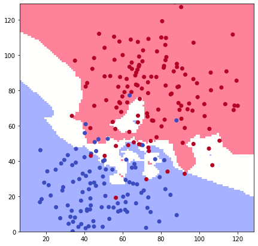

```python
plot_decision_boundaries(X_test['speed'], X_test['angle'], y_test, clf)
```

**Análisis:** Analizad los resultados obtenidos y, en especial, la frontera de decisión.

### 2.2.2 SVM (Suport vector machines)

**Implementació:** Entrena un SVM con gamma = 0.07 sobre el conjunto de datos de train. A continuación evalua sobre test y calcula su precisión aplicando validación cruzada con 5 conjuntos. Finalmente, dibuja la frontera de decisión. NOTA: para que funcione la función de las fronteras de decisión se tiene que especificar "probability = True" al inicializar el modelo.

**Solución:**

```python
#############################################
# SOLUCION                                  #
#############################################

clf = svm.SVC(gamma= 0.07, probability=True)

cvscores = cross_val_score(clf, X_train, y_train, cv=5)
print("Precisió mitjana obtinguda amb CV: {:.2f} +/- {:.2f} %".format(np.mean(cvscores)*100, np.std(cvscores)*100))
```

```
Precisió mitjana obtinguda amb CV: 82.28 +/- 6.94 %
```

```python
clf.fit(X_train, y_train)
y_pred_svm = clf.predict(X_test)
accuracy_score(y_pred_svm, y_test)
```

```
0.8836206896551724
```

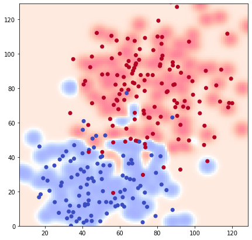

```python
plot_decision_boundaries(X_test['speed'], X_test['angle'], y_test, clf)
```

**Análisis:** Analizad los resultados obtenidos y, en especial, la frontera de decisión.

### 2.2.1 *Stacking*

Un clasificador de *stacking* usa como atributos las predicciones hechas por otros clasificadores en lugar de los datos originales de entrada.

**Implementación:** Construye un clasificador de *stacking* usando un *Gradient Boosting* (con **20 árboles** de decisión y **profundidad máxima de 3** niveles) que use como atributos las predicciones hechas en el conjunto de test por los algoritmos: - árbol de decisión - knn - svm Calcula la precisión del modelo resultante con *cross-validation* en el conjunto de test (en este caso no tenemos conjunto de train, con lo cual se hace directamente cross-validation sobre test). Sugerencia: usar la función column_stack de numpy para juntar todas las predicciones. Per apender a usar esta función os recomendamos el siguiente enlace: - https://docs.scipy.org/doc/numpy-1.14.0/reference/generated/numpy.column_stack.html

**Solución:**

```python
#############################################
# SOLUCION                                  #
#############################################

X_test_stacking = np.column_stack((y_pred_tree,
                                   y_pred_knn,
                                   y_pred_svm))
print("Final dataset dimension: {}".format(np.shape(X_test_stacking)))

clf = ensemble.GradientBoostingClassifier(n_estimators=20, max_depth=3)
cvscores = cross_val_score(clf, X_test_stacking, y_test, cv=5)
print("Precisió mitjana obtinguda amb CV: {:.2f} +/- {:.2f} %".format(np.mean(cvscores)*100, np.std(cvscores)*100))
```

```
Final dataset dimension: (232, 3)
Precisió mitjana obtinguda amb CV: 91.79 +/- 3.75 %
```

**Análisis:** Has conseguido mejorar la precisión gracias al *stacking*? Comenta los resultados.

## 2.2.2. *Cascading*

El caso de *cascading* es parecido al de *stacking* pero utilizando no solamente las predicciones parciales de los clasificadores base, sino también los datos originales.

**Implementación:** Construye un clasificador de *cascading* usando un *Gradient Boosting* (con **20 árboles** de decisión y **profundidad máxima de 3** niveles) que use como atributos las predicciones obtenidas con los modelos anteriores en el conjunto de test (igual que con el *stacking*), y también las variables originales. Calcula la precisión del modelo resultante con *cross-validation* en e conjunto de test. Sugerencia: Usa el mismo conjunto de datos que en el ejercicio anterior pero añade `X_test`.

**Solución:**

```python
#############################################
# SOLUCION                                  #
#############################################

X_test_cascading = np.column_stack((X_test, X_test_stacking))
print("Final dataset dimension: {}".format(np.shape(X_test_cascading)))

clf = ensemble.GradientBoostingClassifier(n_estimators=20, max_depth=3)
cvscores = cross_val_score(clf, X_test_cascading, y_test, cv=5)
print("Precisió mitjana obtinguda amb CV: {:.2f} +/- {:.2f} %".format(np.mean(cvscores)*100, np.std(cvscores)*100))
```

```
Final dataset dimension: (232, 5)
Precisió mitjana obtinguda amb CV: 93.52 +/- 4.08 %
```

**Análisis:** Has conseguido mejorar la precisión gracias al *cascading*? Comenta los resultados.